# Supervised Learning - Foundations Project: ReCell

### TEST FOR LINEARITY AND INDEPENDENCE

- We will test for linearity and independence by making a plot of fitted values vs residuals and checking for patterns.
- If there is no pattern, then we say the model is linear and residuals are independent.
- Otherwise, the model is showing signs of non-linearity and residuals are not independent.

```python
# let us create a dataframe with actual, fitted and residual values
df_pred = pd.DataFrame()

df_pred["Actual Values"] = y_train  # actual values
df_pred["Fitted Values"] = olsmodel2.fittedvalues  # predicted values
df_pred["Residuals"] = olsmodel2.resid  # residuals

df_pred.head()
```

|  | Actual Values | Fitted Values | Residuals |
| --- | --- | --- | --- |
| 3026 | 4.087488 | 3.855637 | 0.231851 |
| 1525 | 4.448399 | 4.627645 | -0.179246 |
| 1128 | 4.315353 | 4.281712 | 0.033640 |
| 3003 | 4.282068 | 4.238675 | 0.043393 |
| 2907 | 4.456438 | 4.474552 | -0.018114 |

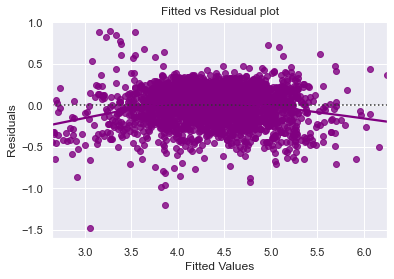

```python
# let's plot the fitted values vs residuals

sns.residplot(
    data=df_pred, x="Fitted Values", y="Residuals", color="purple", lowess=True
)
plt.xlabel("Fitted Values")
plt.ylabel("Residuals")
plt.title("Fitted vs Residual plot")
plt.show()
```

**The scatter plot shows the distribution of residuals (errors) vs fitted values (predicted values).**

**If there exist any pattern in this plot, we consider it as signs of non-linearity in the data and a pattern means that the model doesn't capture non-linear effects.**

**We see no pattern in the plot above. Hence, the assumptions of linearity and independence are satisfied.**

### TEST FOR NORMALITY

- We will test for normality by checking the distribution of residuals, by checking the Q-Q plot of residuals, and by using the Shapiro-Wilk test.
- If the residuals follow a normal distribution, they will make a straight line plot, otherwise not.
- If the p-value of the Shapiro-Wilk test is greater than 0.05, we can say the residuals are normally distributed.

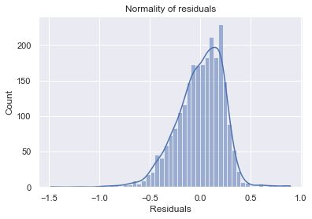

```python
# histogram plot of the residual
sns.histplot(data=df_pred, x="Residuals", kde=True)
plt.title("Normality of residuals")
plt.show()
```

## observation

### Let's check the Q-Q plot.

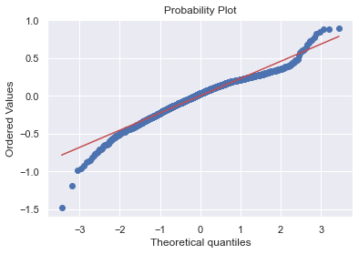

```python
import pylab
import scipy.stats as stats

stats.probplot(df_pred["Residuals"], dist="norm", plot=pylab)
plt.show()
```

**The residuals more or less follow a straight line except for the tails.**

## Let's use shapiro test for normality

```python
stats.shapiro(df_pred["Residuals"])
```

```
ShapiroResult(statistic=0.969283401966095, pvalue=2.4801352671106378e-22)
```

**Since p-value < 0.05, the residuals are not normal as per the Shapiro-Wilk test, the residuals are not normal.**

**However, as an approximation, we can accept this distribution as close to being normal.**

**So, the assumption is satisfied.**

### TEST FOR HOMOSCEDASTICITY

**We will test for homoscedasticity by using the goldfeldquandt test.**

**If we get a p-value greater than 0.05, we can say that the residuals are homoscedastic. Otherwise, they are heteroscedastic.**

```python
import statsmodels.stats.api as sms  # goldfeldquandt test for homoscedasticity
from statsmodels.compat import lzip

name = ["F statistic", "p-value"]
test = sms.het_goldfeldquandt(df_pred["Residuals"], X_train4)
lzip(name, test)
```

```
[('F statistic', 1.049145007506387), ('p-value', 0.20369231172349372)]
```

**Since p-value > 0.05, we can say that the residuals are homoscedastic. So, this assumption is satisfied.**

## Final Model

```python
olsmodel_final = sm.OLS(y_train, X_train4).fit()
print(olsmodel_final.summary())
```

```
                              OLS Regression Results
=================================================================================
Dep. Variable:     normalized_used_price   R-squared:                       0.843
Model:                               OLS   Adj. R-squared:                  0.842
Method:                    Least Squares   F-statistic:                     918.5
Date:                   Thu, 07 Jul 2022   Prob (F-statistic):               0.00
Time:                           04:52:11   Log-Likelihood:                 106.20
No. Observations:                   2417   AIC:                            -182.4
Df Residuals:                       2402   BIC:                            -95.55
Df Model:                             14
Covariance Type:               nonrobust
========================================================================================
                           coef    std err          t      P>|t|      [0.025      0.975]
----------------------------------------------------------------------------------------
const                    1.3803      0.052     26.693      0.000       1.279       1.482
screen_size              0.0254      0.003      7.683      0.000       0.019       0.032
main_camera_mp           0.0207      0.001     15.298      0.000       0.018       0.023
selfie_camera_mp         0.0141      0.001     13.367      0.000       0.012       0.016
ram                      0.0210      0.004      4.733      0.000       0.012       0.030
battery              -1.459e-05   7.12e-06     -2.051      0.040   -2.85e-05   -6.37e-07
weight                   0.0009      0.000      7.148      0.000       0.001       0.001
normalized_new_price     0.4233      0.011     39.188      0.000       0.402       0.445
years_since_release     -0.0222      0.004     -6.075      0.000      -0.029      -0.015
brand_name_Lenovo        0.0477      0.021      2.220      0.027       0.006       0.090
brand_name_Nokia         0.0652      0.031      2.132      0.033       0.005       0.125
brand_name_Realme        0.1067      0.045      2.351      0.019       0.018       0.196
brand_name_Xiaomi        0.0988      0.026      3.871      0.000       0.049       0.149
os_Others               -0.0671      0.030     -2.246      0.025      -0.126      -0.009
4g_yes                   0.0469      0.015      3.139      0.002       0.018       0.076
==============================================================================
Omnibus:                      228.912   Durbin-Watson:                   1.907
Prob(Omnibus):                  0.000   Jarque-Bera (JB):              453.321
Skew:                          -0.617   Prob(JB):                     3.65e-99
Kurtosis:                       4.726   Cond. No.                     3.94e+04
==============================================================================

Notes:
[1] Standard Errors assume that the covariance matrix of the errors is correctly specified.
[2] The condition number is large, 3.94e+04. This might indicate that there are
strong multicollinearity or other numerical problems.
```

```python
# checking model performance on train set (seen 70% data)
print("Training Performance\n")
olsmodel_final_train_perf = model_performance_regression(
    olsmodel2, X_train4, y_train
)  ## Complete the code to check the performance on train data
olsmodel_final_train_perf
```

```
Training Performance
```

|  | RMSE | MAE | R-squared | Adj. R-squared | MAPE |
| --- | --- | --- | --- | --- | --- |
| 0 | 0.231569 | 0.181583 | 0.842603 | 0.84162 | 4.35553 |

```python
# checking model performance on test set (seen 30% data)
print("Test Performance\n")
olsmodel_final_test_perf = model_performance_regression(
    olsmodel2, X_test4, y_test
)  ## Complete the code to check performance on test data
olsmodel_final_test_perf
```

```
Test Performance
```

|  | RMSE | MAE | R-squared | Adj. R-squared | MAPE |
| --- | --- | --- | --- | --- | --- |
| 0 | 0.236591 | 0.182584 | 0.844806 | 0.842526 | 4.445379 |

### Observations

**The model is able to explain about 84% of the variation in the data, which is very good.**

**The train and test RMSE and MAE are low and comparable. So, our model is not suffering from overfitting.**

**The MAPE on the test set suggests we can predict within 4.4% of the normalized_used_price.**

**Hence, we can conclude the model olsmodel2 is good for prediction as well as inference purposes.**

### WRITING THE LINEAR REGRESSION EQUATION

```python
# Let us write the equation of linear regression
Equation = "Normalized Used Phone Price ="
print(Equation, end=" ")
for i in range(len(X_train4.columns)):
    if i == 0:
        print(np.round(olsmodel2.params[i], 4), "+", end=" ")
    elif i != len(X_train4.columns) - 1:
        print(
            "(",
            np.round(olsmodel2.params[i], 4),
            ")*(",
            X_train4.columns[i],
            ")",
            "+",
            end="  ",
        )
    else:
        print("(", np.round(olsmodel2.params[i], 4), ")*(", X_train4.columns[i], ")")
```

[output not shown]

### Running predictions

```python
# predictions on the test set
pred = olsmodel2.predict(X_test4)

df_pred_test = pd.DataFrame({"Actual": y_test, "Predicted": pred})
df_pred_test.sample(10, random_state=1)
```

|  | Actual | Predicted |
| --- | --- | --- |
| 1995 | 4.566741 | 4.372554 |
| 2341 | 3.696103 | 3.963793 |
| 1913 | 3.592093 | 3.690235 |
| 688 | 4.306495 | 4.113930 |
| 650 | 4.522115 | 5.143106 |
| 2291 | 4.259294 | 4.393368 |
| 40 | 4.997685 | 5.447476 |
| 1884 | 3.875359 | 4.057874 |
| 2538 | 4.206631 | 4.049849 |
| 45 | 5.380450 | 5.293625 |

**The actual and predicted values are very comparable meaning our model is very good**

**Using a random sample of 20 data set to show the comparison between actual and predicted values, the result is given below**

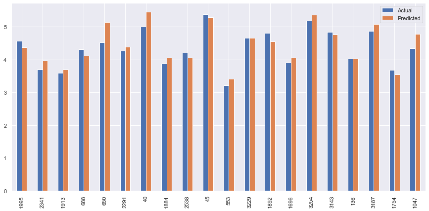

```python
df6 = df_pred_test.sample(20, random_state=1)
df6.plot(kind="bar", figsize=(15, 7))
plt.show()
```

### 1. What does the distribution of normalized used device prices look like?

**The distribution follows an almost normal distribution as the mean is almost equal to the median as shown from the box plot and the statistical summary of the normalized_used_price but the outliers also makes the distribution very slightly left skewed as shown from the histogram.**

**Outliers exist as shown from the boxplot which is indicative of the fact that some phones were very cheap compared to others while some were very expensive.**

**Mean normalized_used_price is 4.36 euros while median normalized_used_price is 4.40.**

### 2. What percentage of the used device market is dominated by Android devices?

**93.1% of the used device is dominated by androif devices**

**windows and ios account for 1.9% and 1% of used device market respectively while other os accounts for 4.0% of the used device market**

### 3. The amount of RAM is important for the smooth functioning of a device. How does the amount of RAM vary with the brand?

**All brands produce phones having 4GB ram**

**Few brands produce phones with 6GB & 8GB RAM phones.**

### 4. A large battery often increases a device's weight, making it feel uncomfortable in the hands. How does the weight vary for phones and tablets offering large batteries (more than 4500 mAh)?

**batteries larger than 4500mAh are not produced by all the brands as shown above**

**Weight of phones having large batteries varies between 200 and 800g**

### 5. Bigger screens are desirable for entertainment purposes as they offer a better viewing experience. How many phones and tablets are available across different brands with a screen size larger than 6 inches?

**celkon, Blackberry and lava have no entries for screen size larger than 6 inches**

**1099 Phones and tablets are available across brands with screen size greater than 6inches**

**Almost all brands produce a certain number of phones with screen size greater than 6inches**

### 6. A lot of devices nowadays offer great selfie cameras, allowing us to capture our favorite moments with loved ones. What is the distribution of devices offering greater than 8MP selfie cameras across brands?

**The distribution of devices offering gretaer than 8MP selfie camera across brands in relation to normalized used price shows a left skewed distribution with very few outliers to the left of the box plot. This is also true for phones with selfie camera's more than 8MP in relation to the normalized new price.**

### 7. Which attributes are highly correlated with the normalized price of a used device?

**normalized_used_price is highly correlated with normalized_new_price which means the higher the new price the higher the used price tends to increase.**

**normalized_used_price also moderately correlated with ram and selfie_camera_mp meaning the higher the phone ram or selfie camera pixels the higher the price of the used phone.**

**normalized_used_price is correlated negatively with days_used which can mean that the longer the duration the phone was used the lower the price of such used phone.**

## Insights and conclusions

**Factors that affects influence the price of normalized used phones include screen_size,main_camera_mp,selfie_camera_mp,ram,battery,weight,normalized_new_price,years_since_release,os_others,4g_yes,brand_name-lenovo,brand_name_nokia,brand_name_realme,brand_name_xiaomi**

**Phone price have a constant decrease in price immediatelty after purchase**

**new_price comes out to be very significant, as expected. An increase in the price of new phone will lead to an increase in the price of used phone.**

**The longer the phone has been used, the lower the used price.**

**Recently release phones have high used price**

## Recommendation

**The model can be used to predict the price of used phone**

**Phones that has been used for long period have poor used/resale price. Investment in such phones is discouraged.**

**Recently released phones should also be focused on as they have a high resale price.**